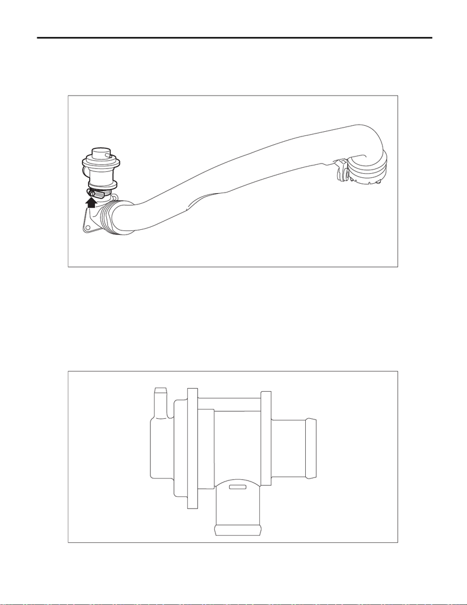

Air By-pass Valve

INTAKE (INDUCTION)

11.Air By-pass Valve

A: REMOVAL

1) Remove the intake duct No. 2. <Ref. to IN(w/o STI)-25, INTAKE DUCT NO. 2, REMOVAL, Intake Duct.>

2) Remove the air by-pass valve from the intake duct No. 2.

B: INSTALLATION

Install in the reverse order of removal.

Tightening torque:

3 N·m (0.3 kgf-m, 2.2 ft-lb)

C: INSPECTION

1. AIR BY-PASS VALVE

1) Check that the air by-pass valve has no deformation, cracks or other damages.

2) Connect the Mighty Vac to the nipple (A) of the air by-pass valve.

IN-03239

IN-03266

(A)

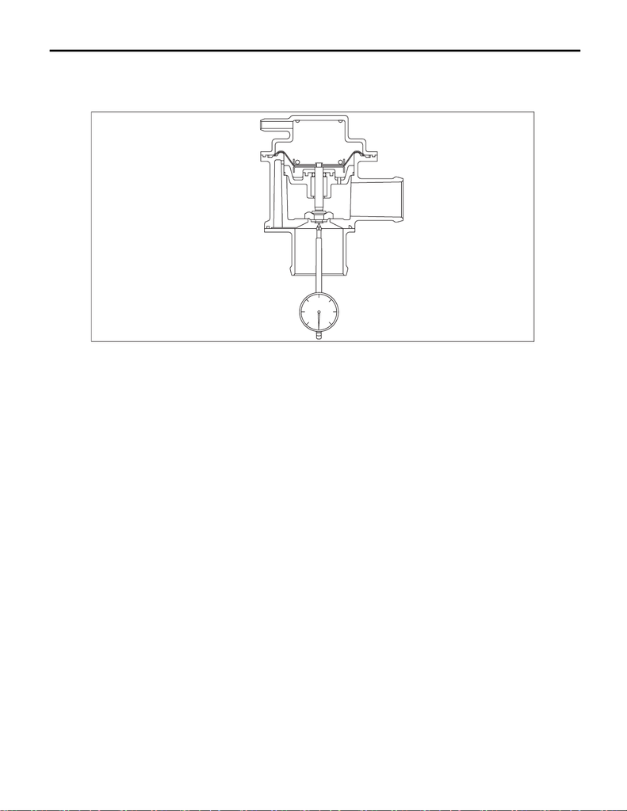

Air By-pass Valve

INTAKE (INDUCTION)

, –13.5 psi). Check that

the Mighty Vac gauge needle indication holds 10 seconds without dropping down to lower than –92.6 kPa

, –13.4 psi).

4) Set a dial gauge to the end of valve rod of the air by-pass valve.

5) Using the Mighty Vac, generate the vacuum pressure, and check the pressure when dial gauge needle

(valve stroke) shows 0.5 mm (0.02 in). If it is not within the standard, replace the air by-pass valve.

Opening pressure (valve stroke 0.5 mm (0.02 in)):

Standard

, –1.93 — –3.09 psi)

2. OTHER INSPECTIONS

Check that the vacuum hose and air by-pass pipe have no cracks, damage or loose part.